# Continuous Traits on Phylogenies

Heath Blackmon

3/8/2019

## Visualizing traits

For starters lets just try simulating a tree and some data and plotting the values for our trait onto the tree

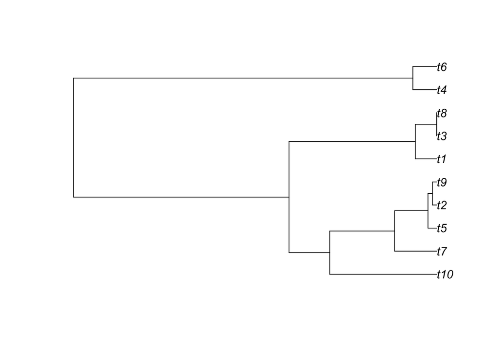

```r
# first load ape
library(ape)

# lets simulate a tree and data
set.seed(10)
tree <- rcoal(10)
trait <- round(rTraitCont(tree), digits=3)

# lets plot the tree to see what it looks like
plot(tree)
```

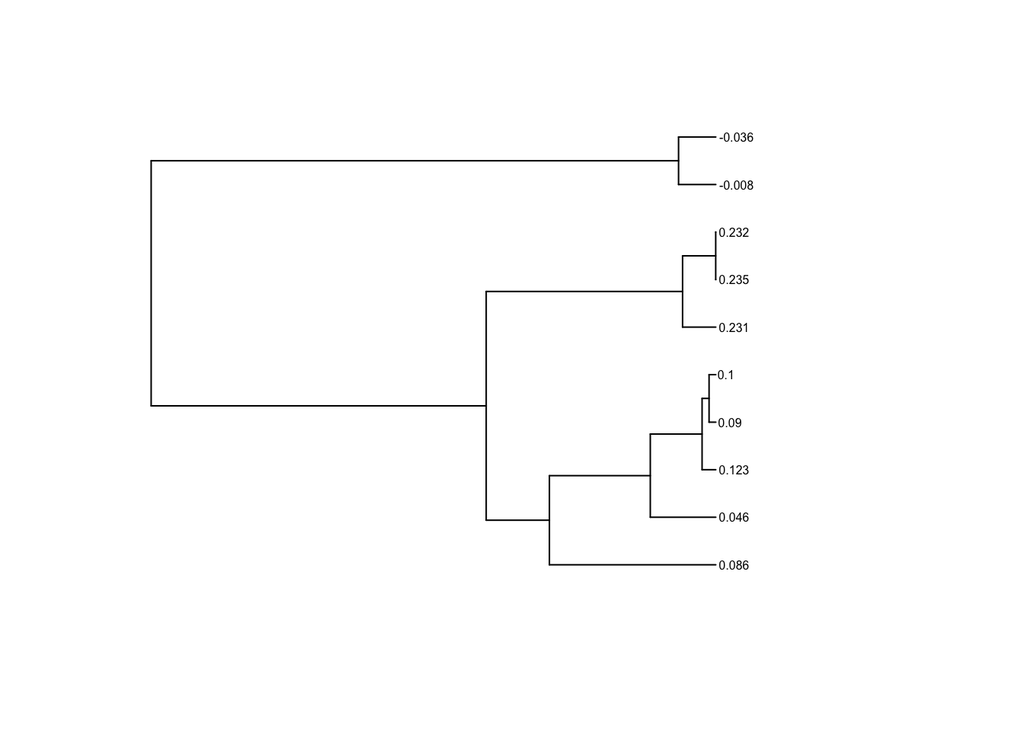

```r
# we might want to add values to the tips of the tree
plot(tree, show.tip.label = F, x.lim=c(0,3))
tiplabels(text=trait, frame="none",cex=.5, adj=-.1)
```

Try simulating your own tree and data and plotting it.

## Ancestral state reconstruction

Reconstructing ancestral states is central to many analyses in evolutionary biology. If we have a continuous trait we usually reconstruct trait values based on the assumption of a model of Brownian motion (although more complex models can be used). If we are only interested in values at different nodes in a tree we can use the R package `ape`. Here is an example

```r
# lets simulate that data again
set.seed(10)
tree <- rcoal(10)
trait <- round(rTraitCont(tree), digits=3)
# this function will return ancestral
# states for each node in the tree
anc.states <- ace(phy=tree, x=trait)
# the maximum likelihood reconstruction is stored in
# the second element of the list returned it is named ace
anc.states[[2]]
```

```
##          11          12          13          14          15          16
##  0.07007030  0.12656560  0.10585824  0.08484638 -0.01886012  0.22401233
##          17          18          19
##  0.10477140  0.09817787  0.23348764
```

```r
# or
anc.states$ace
```

```
##          11          12          13          14          15          16
##  0.07007030  0.12656560  0.10585824  0.08484638 -0.01886012  0.22401233
##          17          18          19
##  0.10477140  0.09817787  0.23348764
```

```r
# we can also extract the 95% confidence interval for
# alpha parameter which describes the rate of evolution
anc.states$sigma2
```

```
## [1] 0.005858183 0.002709647
```

```r
# we can also extract the 95% confidence interval for
# the value at each node:
anc.states$CI95
```

```
##           [,1]       [,2]
## 11 -0.09516379 0.23530438
## 12  0.03292779 0.22020341
## 13  0.02554540 0.18617109
## 14  0.02951137 0.14018140
## 15 -0.06474090 0.02702066
## 16  0.18137603 0.26664864
## 17  0.07942103 0.13012177
## 18  0.08001543 0.11634031
## 19  0.23125639 0.23571889
```

The reconstructions in the ace list are ordered the same way as the nodes in the tree are try using the function `nodelabels` to place these ancestral state reconstructions onto the tree.

## Visualizing ancestral states

The package `phytools` allows some great visualizations of ancestral states for instance lets paint our tree branches with ancestral states rather than just labeling them:

```r
# first load phytools
library(phytools)
```

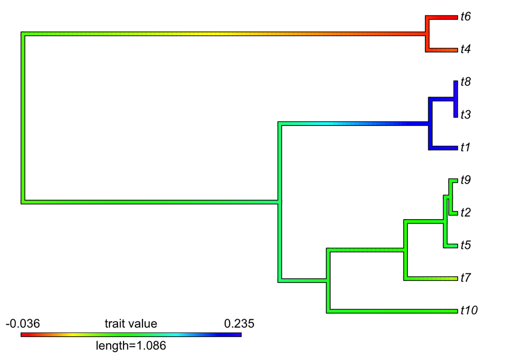

```r
# lets simulate that data again
set.seed(10)
tree <- rcoal(10)
trait <- round(rTraitCont(tree), digits=3)
# now lets use contmap to do the ancestral state construction
anc.state.map <- contMap(tree=tree, x= trait)
```

Try changing this to a circular tree or for a real challenge try changing the color pallete used. The object returned by `contMap` contains an object cols that you will need to edit to change the colors. Good luck!